# Economic Downturn, Turnout, and Incumbent Support

Final Report – STA 702 Statistical Analysis Project

Author

Diwas Purin, Tony Ngari, Tea Tafaj, Xinhao Zhang

Published

December 10, 2025

# Executive Summary

Local economic conditions influence both *who votes* and *which party voters support*, but in very different ways.  
Using county-level data from 2000–2022, we examine how changes in unemployment relate to **voter turnout** and **support for the incumbent presidential party**.

**Turnout (Research Question 1 Related):**  
Across election cycles, turnout is shaped primarily by election type and stable county characteristics. Local economic downturns have only a weak and modest effect: when unemployment rises within a county, turnout increases slightly, but the change is small. Rural, suburban, and urban counties show different patterns, yet the practical impact of unemployment on participation remains limited.

**Incumbent Support (Research Question 2 Related):**  
In contrast, deteriorating local economic conditions meaningfully reduce support for the incumbent presidential party. Counties experiencing worse-than-usual unemployment are less likely to vote for the president’s party, even after accounting for long-standing political differences and national election dynamics. This economic penalty is strongest in rural counties and most muted in suburban and urban areas.  
Recent elections, however, reveal exceptions—some economically distressed rural counties continued supporting Republican incumbents—reflecting broader partisan realignment.

**Overall Insight:** Economic downturns do little to alter *who turns out*, but they substantially shape *how counties vote*. The clearest pattern is retrospective accountability: when local economic conditions worsen, incumbents generally face electoral punishment.

# Stakeholder

**Primary stakeholder:** Campaign Strategists and Political Analysts

**The stakeholder needs to understand:**

- Whether local economic downturns mobilize new voters to the polls (Turnout).
- Whether voters consistently punish incumbents for local economic pain (Vote Choice).
- How these patterns differ across Rural, Suburban, and Urban battlegrounds to optimize resource allocation.

The memo provides high-level insights to guide campaign **resource allocation**, **geographic targeting**, and **message strategy**.  
All technical specifications, modeling details, and diagnostics are deferred to the Technical Appendix.

# Background and Motivation

Economic conditions shape political behavior in multiple ways. When local economies weaken, some voters who typically participate inconsistently may become more engaged, either to express dissatisfaction or to influence change. At the same time, voters often evaluate the incumbent party based on how well they believe the economy is performing, rewarding improvement and penalizing downturns.

Most research has focused on national-level trends, but economic conditions vary widely across places. This project examines whether *local* labor-market changes—specifically rising unemployment within a county—affect two outcomes at the county level: **voter turnout** and **support for the incumbent presidential party**. Understanding these local dynamics can help campaigns and policymakers anticipate how economic stress may influence electoral behavior across different types of communities.

# Data Description

Our analysis uses a multi-year county-level dataset combining data from the **Inter-university Consortium for Political and Social Research (ICPSR)** and the **Bureau of Labor Statistics (BLS)**:

- **General election turnout** for all U.S. counties from 2004–2022.
- **Presidential election results**, used to determine whether the incumbent party carried each county.
- **Local economic conditions**, measured through county-year unemployment rates.
- **County classifications** (urban, suburban, rural), constructed using population and voting-eligible population indicators to assess heterogeneous responses.

The dataset spans more than 20 years of election cycles and includes both presidential and midterm elections.  
**Details** on data construction, variable definitions, merging procedures, and coding steps appear in the **Technical Appendix.**

# Research Question 1 Key Findings

**RQ1:** *How does local unemployment relate to voter turnout in U.S. elections at the county level?*

**Findings:**

- **Interaction Effects are Significant:** Statistical testing confirms that the relationship between unemployment and turnout differs meaningfully across **Rural**, **Suburban**, and **Urban** counties. The effect cannot be treated as uniform across all geographies.
- **Modest Substantive Impact:** While statistically significant, the economic effect sizes are small. A massive 2 percentage point increase in unemployment (recession scenario) predicts turnout changes of less than **0.5 percentage points** across all county types.
- **Rural Baseline:** In rural counties (reference group), a 1% increase in unemployment is associated with a negligible increase in turnout (~0.04 percentage points).
- **Urban/Suburban Response:** Urban and suburban counties show slightly larger positive responses to unemployment than rural counties, but the effects remain substantively modest (< 0.25 percentage points per 1% unemployment).

**Visual Evidence:**

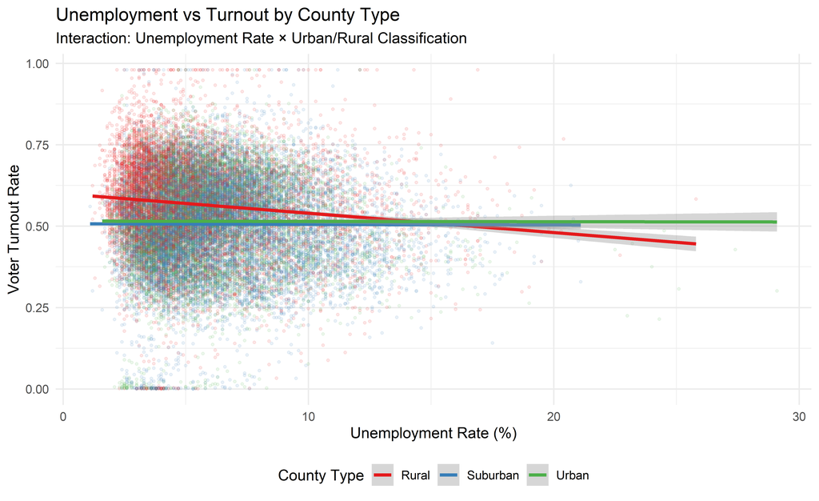

Interaction Effect: The relationship between unemployment and turnout varies by county type.

# Research Question 2 Key Findings

**RQ2:** *Does local economic downturn affect the probability that a county supports the incumbent presidential party?*

**Findings:**

- **Local economic downturns clearly reduce support for the incumbent presidential party.** When unemployment in a county is higher than usual for that county, the incumbent is noticeably less likely to carry it, even after accounting for long-standing political differences and overall national trends.
- **The effect is concentrated in places facing serious economic distress.** At low and moderate unemployment levels, incumbent support changes little, but in counties with high and especially very high unemployment, support for the incumbent drops sharply.
- **Rural counties are the most sensitive to local economic conditions.** Across the unemployment distribution, rural areas show the largest declines in incumbent support as unemployment rises, while the relationship is more muted in suburban and urban counties.
- **Recent elections reveal important exceptions.** In 2016 and 2020, some high-unemployment rural counties actually showed **higher** support for the Republican incumbent, reflecting a broader partisan realignment in which party loyalty can override local economic pain.
- **Overall, the pattern is consistent with retrospective economic voting.** Voters generally punish incumbents when local economic conditions worsen, but this accountability mechanism is tempered in places where partisan identities have become especially strong.

# Policy Implications

- Economic conditions play a **limited** role in shaping voter turnout but have a clearer impact on support for the incumbent presidential party, especially when unemployment rises.
- Campaigns should target **economic messaging** toward counties experiencing severe distress, with particular attention to **rural areas**, which are most responsive to worsening conditions.
- Electoral strategies should also recognize that urban, suburban, and rural counties **react differently** to economic stress, and places undergoing partisan realignment may require alternative communication approaches.
- Mobilization efforts will remain more effective when focused on **structural and institutional factors**—such as registration and voting access—rather than relying solely on economic improvements to boost participation.

# Limitations

- Our analysis relies on county-level data, which cannot capture **individual voting behavior** or the mechanisms driving turnout and vote choice.
- Unemployment is only **one aspect of local economic conditions**; other forms of economic distress—such as wage changes, housing instability, or industry decline—are not included.
- County fixed effects enable within-county comparison but cannot fully account for **long-term partisan shifts** that may interact with economic conditions, particularly in rural areas after 2012.
- The outcome measures rely on **two-party presidential results**, which exclude third-party dynamics and Senate-level variation.

All methodological limitations, robustness checks, and model diagnostics are documented in the Technical Appendix.

# Appendix

## 1. Data Sources and Construction

We construct a county–year panel dataset by merging turnout, presidential election results, and local unemployment data.

- **Turnout data:** County-level general election turnout for U.S. counties (2004–2022).
- **Presidential election results:** Democratic and Republican vote totals, used to construct `winner_party` and `incumbent_party`.
- **Local economic conditions:** County unemployment rates from the Bureau of Labor Statistics (BLS).
- **County classifications:** Urban / Suburban / Rural categories based on county population / voting-eligible population.
- **Time period:**
  - **Turnout analysis (RQ1):** 2004–2022
  - **Incumbent support (RQ2):** Presidential elections in 2000, 2004, 2008, 2012, 2016, 2020

**Data processing workflow (summary):**  
We merge turnout, unemployment, and election results by county (`FIPS`) and year, remove missing or unrealistic observations (for example, turnout equal to zero), restrict to presidential years for RQ2, and construct analysis variables used in the models (see A2).

**Cleaning and Sample Definition for RQ1 (Turnout)**

**Construction of Incumbent Support for RQ2**

**County Urbanicity Classification**

## 2. Variable Definitions

- **Voter Turnout Rate:** The proportion of the citizen voting-age population (CVAP) that cast a ballot.
- **Unemployment Rate:** The percentage of the labor force that is unemployed (annual average).
- **Unemployment Tier:** Statistical classification of unemployment severity (low / medium / high) based on historical deviations.
- **Election Type:** Indicator for presidential vs. midterm elections.
- **County Type:** Classification as Urban, Suburban, or Rural based on voting-age population size.
- **Incumbent Win:** Indicator (1/0) if the county voted for the incumbent presidential party.
- **Winner Party:** The party (Democrat/Republican) that received the most votes in the county.
- **Incumbent Party:** The party holding the presidency at the time of the election.
- `FIPS`: County identifier for fixed effects.

## 3. Cleaning and Processing Workflow

1. Import datasets and harmonize county-level identifiers.
2. Merge turnout with unemployment data (RQ1).
3. Merge presidential election results with unemployment (RQ2).
4. Create derived variables (tiers, incumbent indicators, county type).
5. Filter to analysis subsets:
   - All general elections for RQ1
   - Only presidential elections for RQ2
6. Handle missing/unreliable entries (NA removal, turnout = 0).
7. Convert categorical variables to factors required for FE models.

## 4. Modeling Procedures

### **RQ1: Turnout and Local Unemployment**

**Primary Model: Fixed Effects with Interaction**

We estimate a **Two-Way Fixed Effects (TWFE)** model to isolate the within-county effect of unemployment on turnout, controlling for time-invariant county characteristics and national election trends.

$$\text{Turnout}_{it} = \beta_1 \text{Unemployment}_{it} + \beta_2 (\text{Unemployment}_{it} \times \text{CountyType}_i) + \alpha_i + \delta_t + \epsilon_{it}$$

- $\alpha_i$ (County Fixed Effects): Controls for stable characteristics like demographics, political culture, and geography.
- $\delta_t$ (Year Fixed Effects): Controls for national waves (e.g., 2008 surge, 2014 slump).
- **Interaction Term:** Allows the effect of unemployment to vary by Rural (Reference), Suburban, and Urban classifications.
- **F-Test:** Conducted to formally test if the interaction terms significantly improve model fit compared to a base model.

### **RQ2: Economic Downturn and Incumbent Support**

**Fixed-effects logistic regression:**

- County FE absorb time-invariant political traits.
- Year FE absorb national shocks (economy-wide trends, incumbency advantage cycles).
- Identification relies on *within-county* changes.

## 5. Regression Tables

### Table 1: Effect of Unemployment on Voter Turnout (RQ1)

**Effect of Unemployment on Voter Turnout (Fixed Effects Model)**

|  | *Dependent variable:* |
| --- | --- |
|  | Voter Turnout Rate |
| Unemployment Rate (Rural baseline) | 0.0004 |
|  | (0.0006) |
| Unemp × Suburban | -0.0362*** |
|  | (0.0071) |
| Unemp × Urban | -0.0477*** |
|  | (0.0095) |
| unemployment_rate:county_typeSuburban | 0.0015*** |
|  | (0.0006) |
| unemployment_rate:county_typeUrban | 0.0020*** |
|  | (0.0006) |
| Observations | 29,769 |
| R<sup>2</sup> | 0.7415 |
| Adjusted R<sup>2</sup> | 0.7112 |
| *Note:* | *p<0.1; **p<0.05;*** p<0.01 |
|  | Standard errors in parentheses. |
|  | Model includes county and year fixed effects. |
|  | Reference category: Rural counties. |

## 6. Supplementary Figures

### Figure S1: Turnout Trends by Election Type

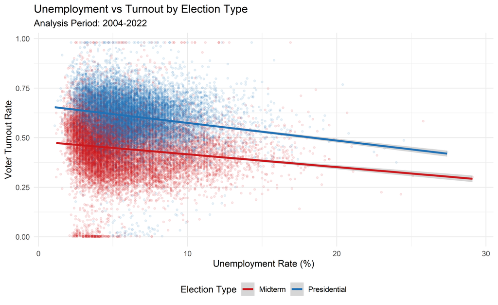

Turnout is driven more by election cycle than economic conditions.

### Figure S2: Distribution of Turnout by Economic Condition

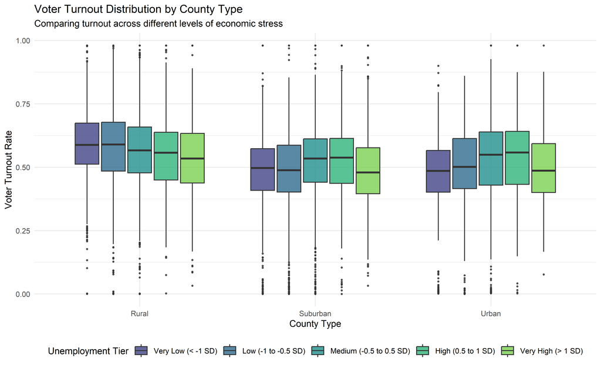

Turnout distributions are stable across economic tiers.